# R Notebook

# 2.1

## 2.1.1 Basic Concepts

Simple practical problem:

[output not shown]

Some of the data are numerical:

- Quantitative and continuous: City distance, engine size, and curb weight (kg)
- Quantitative and discrete: number of cylinders

Matrix of scaterplots of some variables of car data, stratified by fuel type.

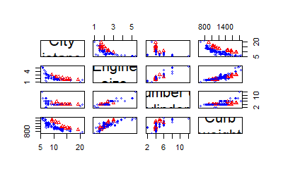

Some are qualitative:

- fuel type: diesel and gasoline

**We will in first phase consider only two explanatory variables:**

- Engine size, fuel type

To study the relationship between quantitative variables we usually make a grafic representation.

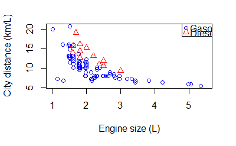

$B(\beta)=\Sigma_{i=1}^n \{y_{i} -f(x_{i};\beta) \}^2 = ||y-f(x;\beta)||^2$

The last expressison is showing the matrix notation for representing $y = (y1,...,y_{n})^T; (f(x_{1};\beta),...,f(x_{m};\beta))^T;$.

**But from what we can see in the plot of ‘city distance against engine size’, a linear model might not be the best.** Therefor we might consider a polynomial form, since it is easy and quick. The polynom will look something like: $f(x;\beta) = \beta_{0} + \beta_{1} x + ... + \beta_{p-1} x^{p-1}$

Because of the simplicity if a polynomial we can wirte f in matrix form with low effort, $f(x;\beta)= X\beta$ where x is an n x p matrix, called the design matrix, defined by $X=(1,x,...,x^{p-1})$ where x is the vector of the observations of the explanatory variable, and the varius columns of X contains powers of order from 0 to p-1 of elements of x.

On the matrix form the solution to the minimaztion problem is $\hat{\beta} = (X^{T}X)^{-1}X^{T}y$

## 2.2 Computational Aspects

When we have alot of data the computation starts becomming important to think about. And the main part of the calculation we need to look at is the function

$\hat{\beta} = (X^{T}*X)^{-1} X^{T} y$ (2.7)

### 2.2.1 Least Squares estimation by Successie Orthogonalization

Most solutions based on least squares problems (2.7) are mostly based on the inversion of the matrix $(X^{T}X)$. However a matrix can only be inverted only if all its rows and coloums are lineary independent. The Gram-Schmidt algorithm transformes gives a new formulation of X with orthogonal columns, so that the inverse of $(X^{T}X)$ can be quickly be calculated. The algorithm might be considered in matrix form by considering the QR decomposition of X as the product of an n x p orthogonal matrix Q, usually normalized so that $Q^{T}Q = I$, and p x p, upper trianglular matrix R. The last square solution is therefor

$\hat{\beta} = R^{-1}Q^{T}y$ and $\hat{y} = QQ^{T}y$

where it is easy to get the inversion of R since it is an upper triangular matrix.